# barcode_QC

Jason Cosgrove (jason.cosgrove@curie.fr) & Louisa Hadj Abed

10/02/2022

# Overview of the experiment

In this experiment (JCW24), MPPs from G6PD-Tg and WT controls were barcoded with the LG22 lentivirus barcode library and then transplanted into WT littermate controls. 3 weeks later bone marrow cells were purified and their DNA was lysed and processed for sequencing.

# Step 1: Read in the data

In this code segment we load in the count matrix. For 4 samples we did PCR3 with either 15 or 30 cycles. After analysing these samples we will proceed with the 30 cycle samples and get rid of the 15 cycle samples

```r
# xcalibr output:
temp_count_matrix <- read.csv("/Users/jasoncosgrove/Dropbox (Team_Perie)/Jason/Experiments/Wet_lab/JCW24_G6PD_barcoding/LentiviralBarcoding_Demultiplexing/outputs/final_matrices/CountMatrix_sampDescription.csv", sep = ",")


#remove the 15 cycle samples where we had a weak band
'%ni%' <- function(x,y)!('%in%'(x,y))
count_matrix <- temp_count_matrix[,colnames(temp_count_matrix) %ni% c("b_M1.TG_TERNEG_B", "b_M2.TG_TERNEG_B", "b_M4.WT_CKITPOS_CD62L.HIGH","a_M4.WT_TERPOS_E")]

#rename the 30 cycle samples to facilitate downstream analysis
colnames(count_matrix)[colnames(count_matrix) == "c_M1.TG_TERNEG_B_30cycles"] <- "b_M1.TG_TERNEG_B"
colnames(count_matrix)[colnames(count_matrix) == "c_M2.TG_TERNEG_B_30cycles"] <- "b_M2.TG_TERNEG_B"
colnames(count_matrix)[colnames(count_matrix) == "c_M4.WT_CKITPOS_CD62L.HIGH_30cycles"] <- "b_M4.WT_CKITPOS_CD62L.HIGH"
colnames(count_matrix)[colnames(count_matrix) == "c_M4.WT_TERPOS_E_30cycles"] <- "a_M4.WT_TERPOS_E"
```

# Step 2: Set the experimental condition

In this experiment we had a pool of WT MPPs and a pool of Tg MPPs which were both barcoded with the same library. Each sample was then split into 4 and injected into irradiated recipients. In this experimental design we need to analyse the samples separately. In this code segment we set the experimental condition and change the condition-specific parameters.

```r
wt.columns <- colnames(count_matrix)[grepl("WT",colnames(count_matrix))]
wt <- data.frame(count_matrix[,c("name",wt.columns)])

tg.columns <- colnames(count_matrix)[grepl("TG",colnames(count_matrix))]
tg <- data.frame(count_matrix[,c("name",tg.columns)])

condition <- "WT"

if(condition == "WT"){

  count_matrix <- wt

  # import files
# metadata have to be create first with the create_met.R script and then can be upload here :
   metadata <- read.csv(paste0("outputs_for_QC/", prefix, "_DUPLICATS_metadata_WT.csv"))

  metadata_analysis<-read.csv(paste0("outputs_for_Analysis/", prefix,
                                     "_ANALYSIS_metadata_WT.csv"), header = TRUE)

  } else if(condition == "TG"){
   count_matrix <- tg

   metadata <- read.csv(paste0("outputs_for_QC/", prefix, "_DUPLICATS_metadata_TG.csv"))
   metadata_analysis<-read.csv(paste0("outputs_for_Analysis/", prefix,
                                     "_ANALYSIS_metadata_TG.csv"), header = TRUE)


  } else
    { print("invalid_condition")
}
```

# Step 3. QC analysis of samples

## I-1. Calculate a/b ratio and average read count

### I-1.a. Plot the total number of reads and a/b ratio per sample

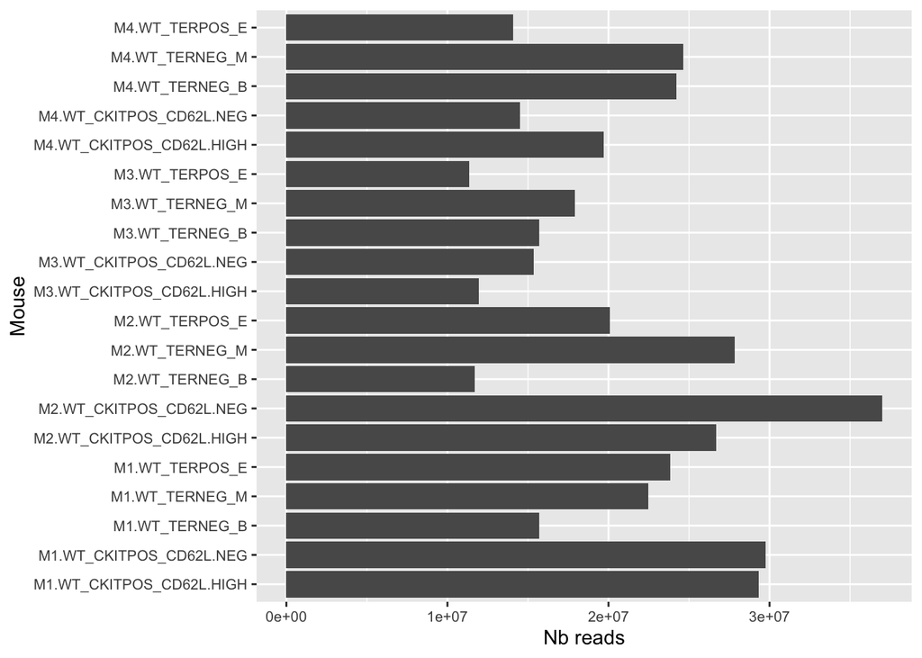

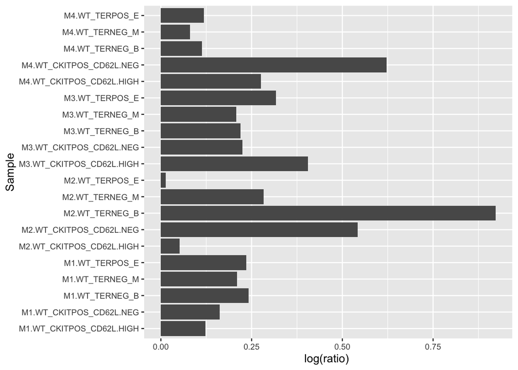

## I-2. Calculate and plot correlations

### I-2.a. Plot normalized data before any filtering

Pearson correlation in title. 1 dote <=> 1 barcode

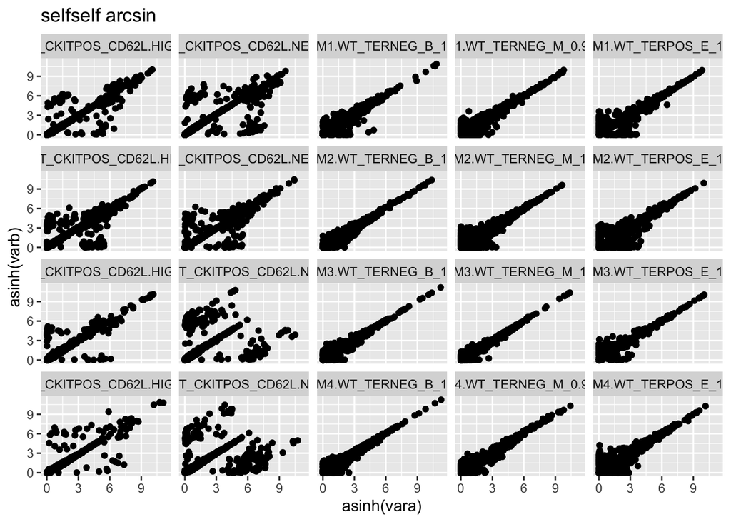

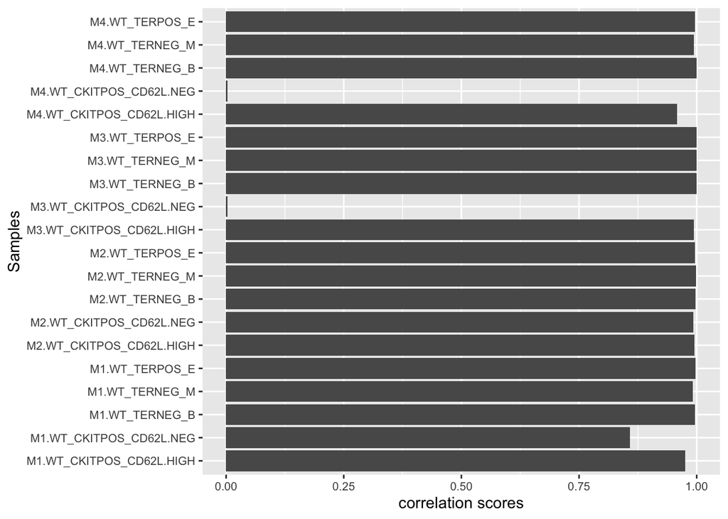

# I-2.b. Plot normalized data after duplicat correlations filtering

## 1st step: Delete samples with a bad correlation score

```r
# 1st step: delete samples with a bad correlation score
#cor_samples_ab<- cor_samples_ab[which(cor_samples_ab$cor>0.75),]
```

## 2nd step: Delete barcodes that are not shared between duplicats

```r
# 2nd step: Delete barcodes that are not shared between duplicats (total barcode abundances per duplicat)

deleteNotDuplicats <- function(matx_ab){
  #here we delete the barcodes not shared between duplicates
  ab_present <- matx_ab[which(matx_ab$vara>0 & matx_ab$varb>0),]
  return(ab_present)
}

#  Filter barcodes on ab present
norm_filt_ab <- deleteNotDuplicats(cor_samples_ab)
nb_bc<-length(unique(norm_filt_ab$tag))
# number of barcodes befor filtering on repeat use
nb_bc
```

```
## [1] 3606
```

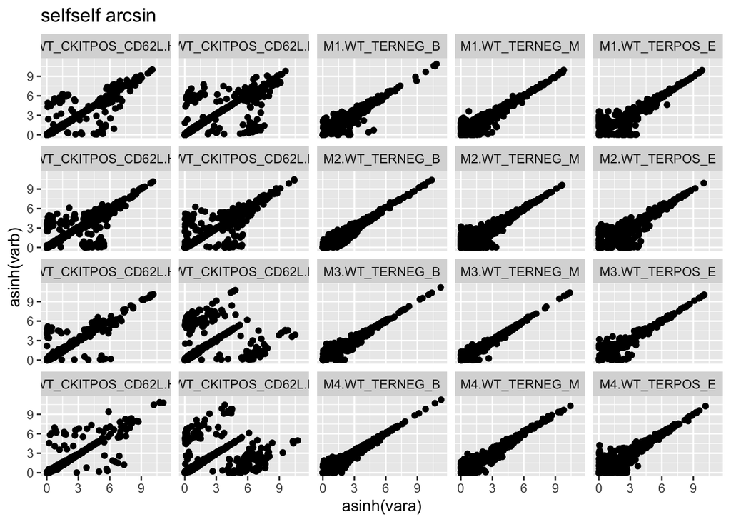

```r
#plot replicates
qplot(asinh(vara), asinh(varb), data=norm_filt_ab) + facet_wrap(~paste(sampleID, sep = "_")) + ggtitle("selfself arcsin")
```

Export table before repeat use control:

```r
# Reformat table to have sample with duplicats names in it
norm_filt_ab_wide<-melt(norm_filt_ab, measure.vars = c("vara", "varb"))
norm_filt_ab_wide$variable<-str_remove(norm_filt_ab_wide$variable, "var")
norm_filt_ab_wide$sampleID<-apply(select(norm_filt_ab_wide, c(variable, sampleID)),  1, function(x) {paste0(x[1], "_", x[2])} )
# long to wide format
finalQC_cor_ab<-dcast(norm_filt_ab_wide, tag~sampleID, value.var = "value")
finalQC_cor_ab[is.na(finalQC_cor_ab)]<-0

# Export filtred matrix on corelations and dupliacts
write.csv(finalQC_cor_ab, paste0("outputs_for_QC/", prefix,condition, "_DUPLICATS_matx_norm_filt_cor_ab.csv"), sep = ",", quote = FALSE, row.names = F)
```

# I-3. Repeat use control

Commonly, if not more than 5% of repeat use (ru) are present, then no treatment is done on this part.

Nevertheless, if more than 5% of repeat use are present, first, delete true ones (quantile method).

And, if after removing true ru barcodes, still more than 5% are present, set false ru to 0 to minimized noise

## I-3.a - Repeat use calculation

Principle: All shared barcodes accross individuals are selected and used to calculate the 95th quantile. This value is used to filter out repeat use.

Repeated barcodes in each individual having less than the quantile value are deleted. The ones that have more than the quantile are kept.

This method allows to limit noise by setting the majority of repeat use to 0 and keep most abundant barcodes which are more likely to be meaningfull.

In the following parts:

- true repeat use = the ones that are deleted because not enough abundant accross indiviudals (<95% in all individuals)
- false repeat use = keep in only one individual and set to 0 in others.

***WARNING WE NEED TO DO THIS FOR WT AND FOR TG SEPARATELY

```r
# Number of barcodes before repeat use filtering
nrow(finalQC_cor_ab)
```

```
## [1] 3606
```

```r
# Get all repeat use
repeat_use<-dcast(norm_filt_ab, tag~mouse, value.var = "total_read", fun.aggregate = sum)

repeat_use$ru<-apply(repeat_use[,-1], 1, function(x) length(which(x>0)))

# summary  (more than one are barcode see in more than one individual)
table(repeat_use$ru)
```

```
##
##    1    2    3    4
##  295  214  287 2810
```

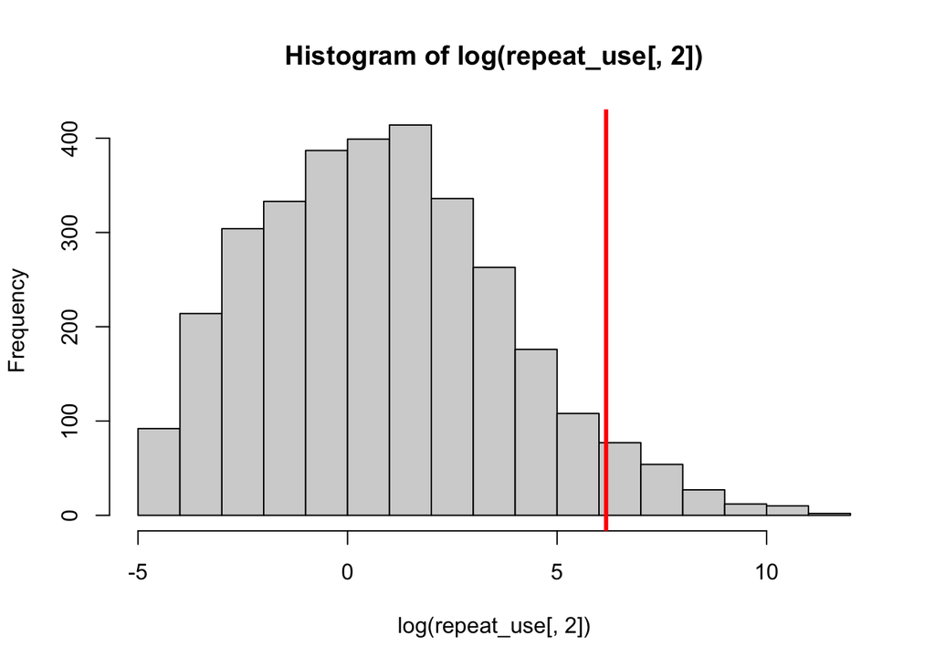

```r
# keep only repeated one across mice
repeat_use<-repeat_use[which(repeat_use$ru>1),]
# Number of all repeat use
nb_ru<-nrow(repeat_use)

######## Almut method
repeat_use <-select(repeat_use, -ru)
# to not take 0 in the calculation of quantile, set them to NA
repeat_use[repeat_use==0]<-NA
rownames(repeat_use)<-repeat_use[,1]
quantile<-quantile(repeat_use[,-1],probs=95/100, na.rm=TRUE)
# les vauleurs inféreures au quantile 95 sont misent à 0 et les autres sont gardées.
repeat_use[is.na(repeat_use)]<-0



# In almuts pipeline the assumption is that most of the repeat use barcodes are noise. Anything below the
# 95th percentile in read abundance per barcode is considered noise and is set to zero
# What we do here is plot the distribution of reads for the true_ru barcodes to see if the 95th percentile
# is a sensible cut off.


#lets see how good our quantile threshold is:
hist(log(repeat_use[,2]))
abline(v = log(quantile), col = "red",lwd = 3)
```

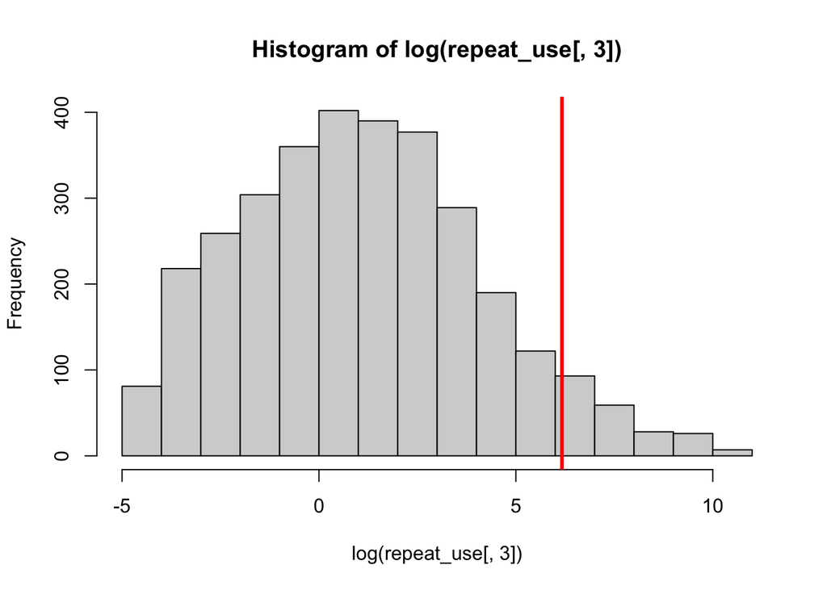

```r
hist(log(repeat_use[,3]))
abline(v = log(quantile), col = "red",lwd = 3)
```

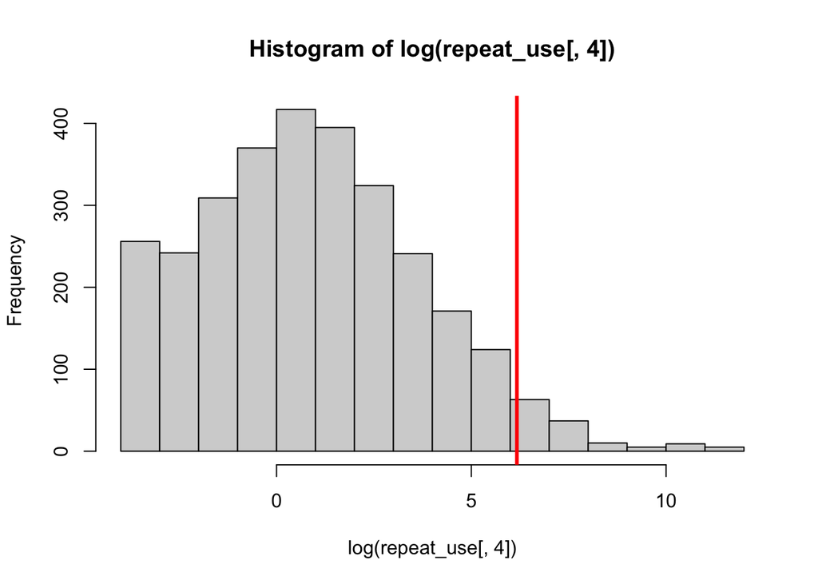

```r
hist(log(repeat_use[,4]))
abline(v = log(quantile), col = "red",lwd = 3)
```

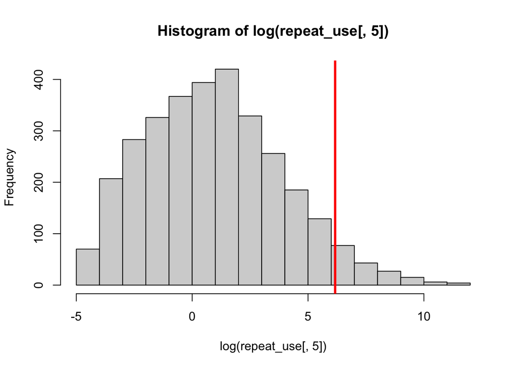

```r
hist(log(repeat_use[,5]))
abline(v = log(quantile), col = "red",lwd = 3)
```

```r
true_repeat_use <- apply(repeat_use[,-1], 2, function(x) ifelse(x < quantile, 0, x))
true_repeat_use<-as.data.frame(true_repeat_use)
nb_true_ru<-nrow(true_repeat_use[which(rowSums(true_repeat_use)==0),])

# Percentage of all repeat use
nb_ru/nb_bc
```

```
## [1] 0.9181919
```

```r
# Percentage of  true ru (low abudnants)
nb_true_ru/nb_bc
```

```
## [1] 0.7728785
```

```r
# Percentage of false ru (highly abundant)
(nb_ru-nb_true_ru)/nb_bc
```

```
## [1] 0.1453134
```

## I-3.b - Filter out true repeat use

```r
#IF NEEDED, depend on your samples quality !!!!!!!!!!

## 2nd filtering = Delete True repeat use

# In the matrix "true_repeat_use" there are barcodes to delete (sum = 0) & barcodes keeped but set to 0 in some mice because they are false repeat use (with low abundance)

# Get true repeat use
barcodes_toDelete<-data.frame(toDelete=rownames(true_repeat_use[which(rowSums(true_repeat_use)==0),]))


norm_filt_ab_trueRu<-filter(norm_filt_ab, !tag %in% barcodes_toDelete$toDelete)


# Reformat long duplicat matrix to wide format to export it as final QC matrix (<=> input of the app)
norm_filt_ab_trueRu_wide<-melt(norm_filt_ab_trueRu, measure.vars = c("vara", "varb"))
norm_filt_ab_trueRu_wide$variable<-str_remove(norm_filt_ab_trueRu_wide$variable, "var")
norm_filt_ab_trueRu_wide$sampleID<-apply(select(norm_filt_ab_trueRu_wide, c(variable, sampleID)),  1, function(x) {paste0(x[1], "_", x[2])} )
# long to wide format
finalQC<-dcast(norm_filt_ab_trueRu_wide, tag~sampleID, value.var = "value")
finalQC[is.na(finalQC)]<-0
# number of barcodes after true ru filtering
nrow(finalQC)
```

```
## [1] 819
```

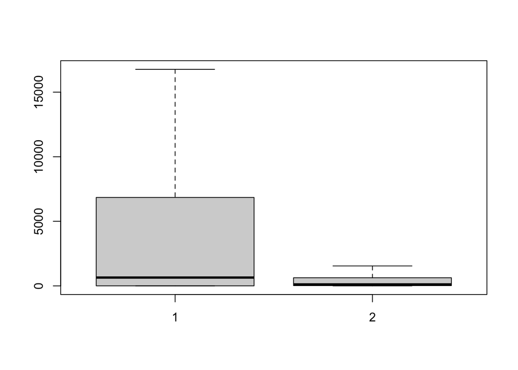

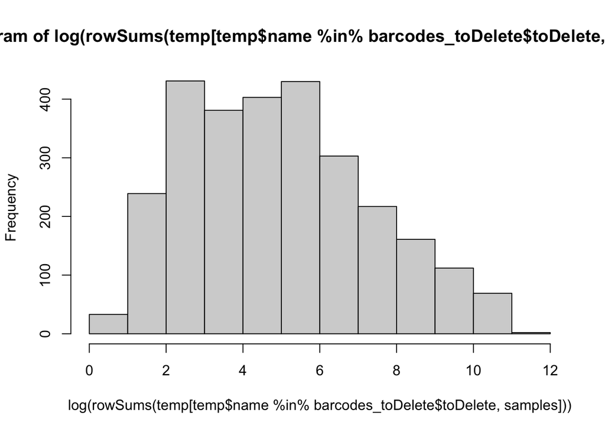

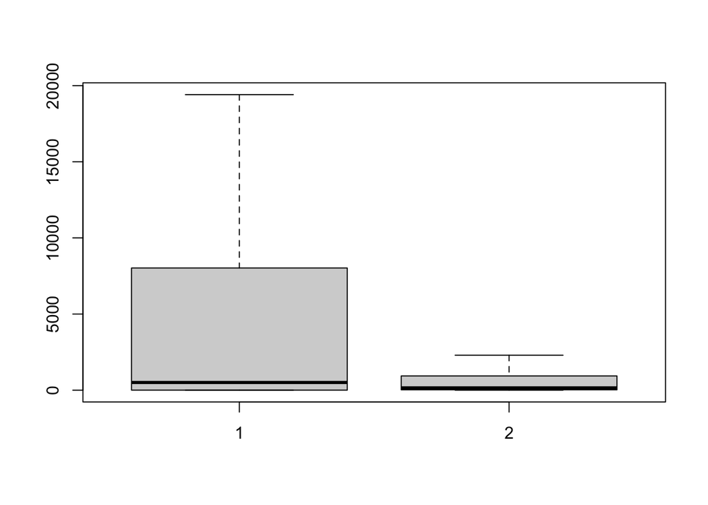

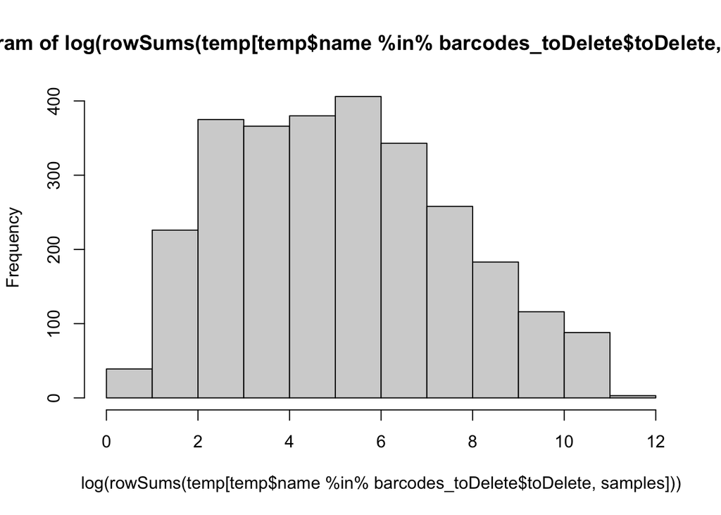

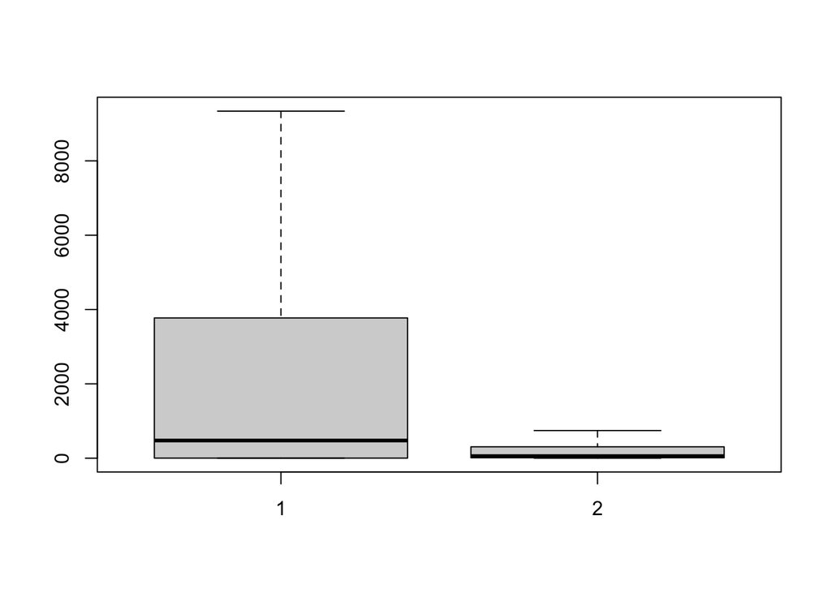

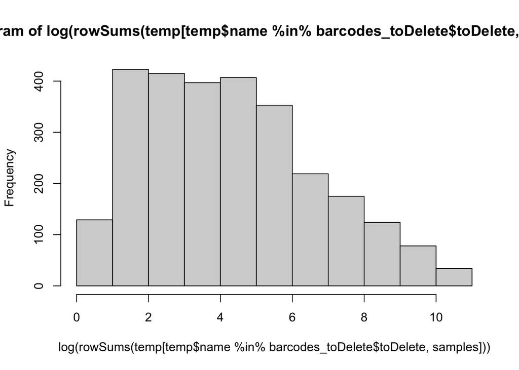

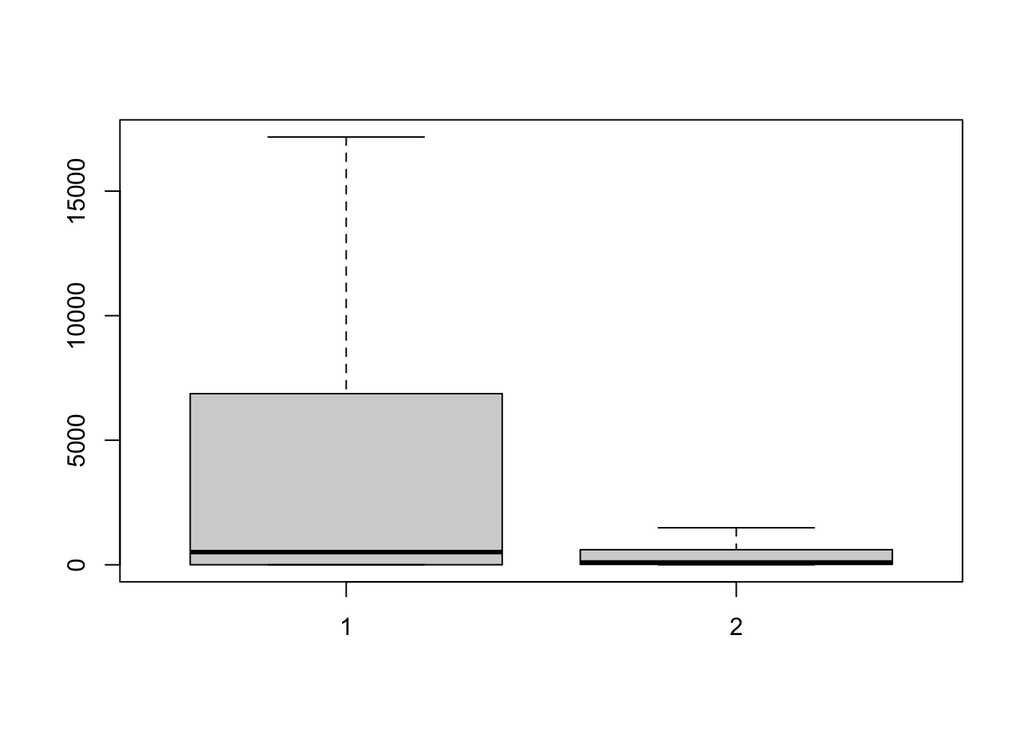

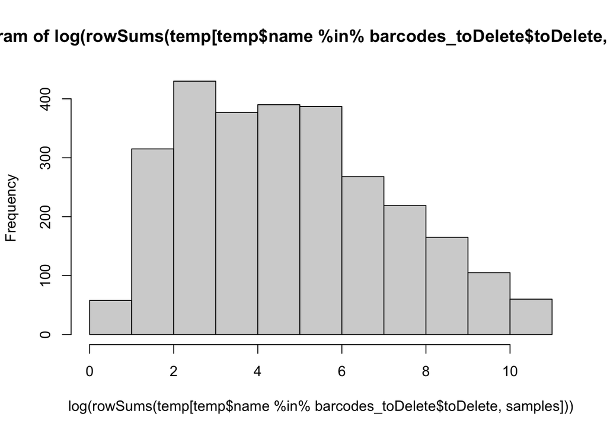

```r
## export QC matrix
write.csv(finalQC,paste0("outputs_for_QC/", prefix,condition ,"_DUPLICATS_matx_norm_filt_cor_ab_trueRU.csv"), sep = ",", quote = FALSE, row.names = F)



mice = c('M1.WT','M2.WT','M3.WT','M4.WT')
for(i in 1:length(mice)){
  samples <- colnames(count_matrix)[grepl(mice[i],colnames(count_matrix))]
  #remove the barcodes which are not in this sample
  temp <- count_matrix[rowSums(count_matrix[,samples]) > 0,]

  boxplot(
  #real barcodes that we want to keep
  rowSums(temp[temp$name %ni% barcodes_toDelete$toDelete,samples]),
  #repeat use barcodes to be deleted
  rowSums(temp[temp$name %in% barcodes_toDelete$toDelete,samples]),outline = F)

  hist(log(rowSums(temp[temp$name %in% barcodes_toDelete$toDelete,samples])))


}
```

## I-3.c - Set false repeat use to 0 in all individual exept one

```r
#IF NEEDED, depend on your samples quality !!!!!!!!!!


## 3rd filtering = false ru barcodes <=> For each "false ru", keep its abundances in one individual set to 0 in others.
true_repeat_use$tag<-rownames(true_repeat_use)
toBalance<-melt(true_repeat_use[which(rowSums(select(true_repeat_use, -tag))>0),], id.vars = "tag")
toBalance<-toBalance[toBalance$value>0,]

lg_filtred<-melt(finalQC, id.vars = "tag")
for( i in 1:nrow(toBalance)){
    # Set them to 0 and keep its values in corresponding mice
    lg_filtred[which(lg_filtred$tag==toBalance[i,]$tag & !grepl(lg_filtred$variable, pattern = paste0("_", toBalance[i,]$variable, "_") )),3]<-0
}

# create matrix filtred on false repeat use
final_trueANDfalse_RU_filtred<-dcast(lg_filtred, tag~variable)
final_trueANDfalse_RU_filtred<-final_trueANDfalse_RU_filtred[rowSums(final_trueANDfalse_RU_filtred[,-1])>0,]

# EXPORT
write.csv(final_trueANDfalse_RU_filtred, paste0("outputs_for_QC/",prefix,condition,"_DUPLICATS_matx_norm_filt_cor_ab_trueFalseRU.csv"), sep = ",", quote = FALSE, row.names = F)
```

End of QC Part.

#####°°°°°°°°°°°°°°°°°°°°°°°°°°°°°°°°°°°°°°°°°°°°°°°°°2nd PART OF THE SCRIPT°°°°°°°°°°°°°°°°°°°°°°°°°°°°°°°°°°°°°°°°°°°°°°°°°°°######

# II - Merge duplicats to create analysis filtred matrix

## II - 1. No repeat use filtering

```r
######### export ANALYSIS Matrix

####### Matrix without repeat use deleteions
# from the filtred duplicats matrix, delete duplicats information and take the sum of both
analysis_matx_lg<-norm_filt_ab_wide
analysis_matx_lg$sampleID<-str_remove(analysis_matx_lg$sampleID, "a_")
analysis_matx_lg$sampleID<-str_remove(analysis_matx_lg$sampleID, "b_")

# long to wide
analysis_matx_wide<-dcast(analysis_matx_lg, tag~sampleID, fun.aggregate = sum, value.var = "value")

write.csv(analysis_matx_wide, paste0("outputs_for_Analysis/", prefix,"_ANALYSIS_matx_norm_filt_cor_ab.csv"), sep = ",", quote = FALSE, row.names = F)
```

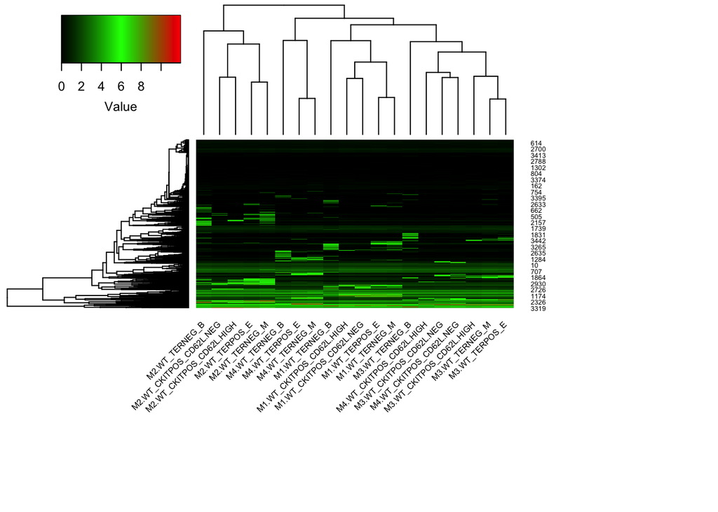

```r
## Plot heatmap

distance<-"euclidean"
clusteringMeth<-"complete"
dendro<-"yes"

p<-plotHeatmap(analysis_matx_wide[,-1], distance,clusteringMeth, dendro)
```

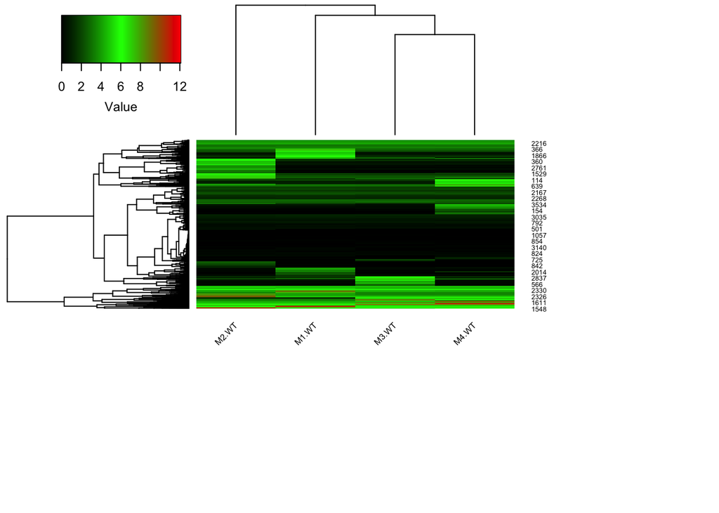

```r
# reformat
matx<-wideToLong(analysis_matx_wide, metadata_analysis )
matx<-filter(matx, counts>0)
matx_mice<-dcast(matx, Barcodes~mouse, fun.aggregate = sum, value.var = "counts")

# plot
p<-plotHeatmap(matx_mice[,-1], distance,clusteringMeth, dendro)
```

## II - 2. True repeat use filtering

```r
####### Matrix with true repeat use deletion

# from the filtred duplicats matrix, delete duplicats information and take the sum of both
analysis_matx_lg<-norm_filt_ab_trueRu_wide
analysis_matx_lg$sampleID<-str_remove(analysis_matx_lg$sampleID, "a_")
analysis_matx_lg$sampleID<-str_remove(analysis_matx_lg$sampleID, "b_")

# long to wide
analysis_matx_wide<-dcast(analysis_matx_lg, tag~sampleID, fun.aggregate = sum, value.var = "value")

write.csv(analysis_matx_wide, paste0("outputs_for_Analysis/", prefix,condition,"_ANALYSIS_matx_norm_filt_cor_ab_trueRU.csv"), sep = ",", quote = FALSE, row.names = F)
```

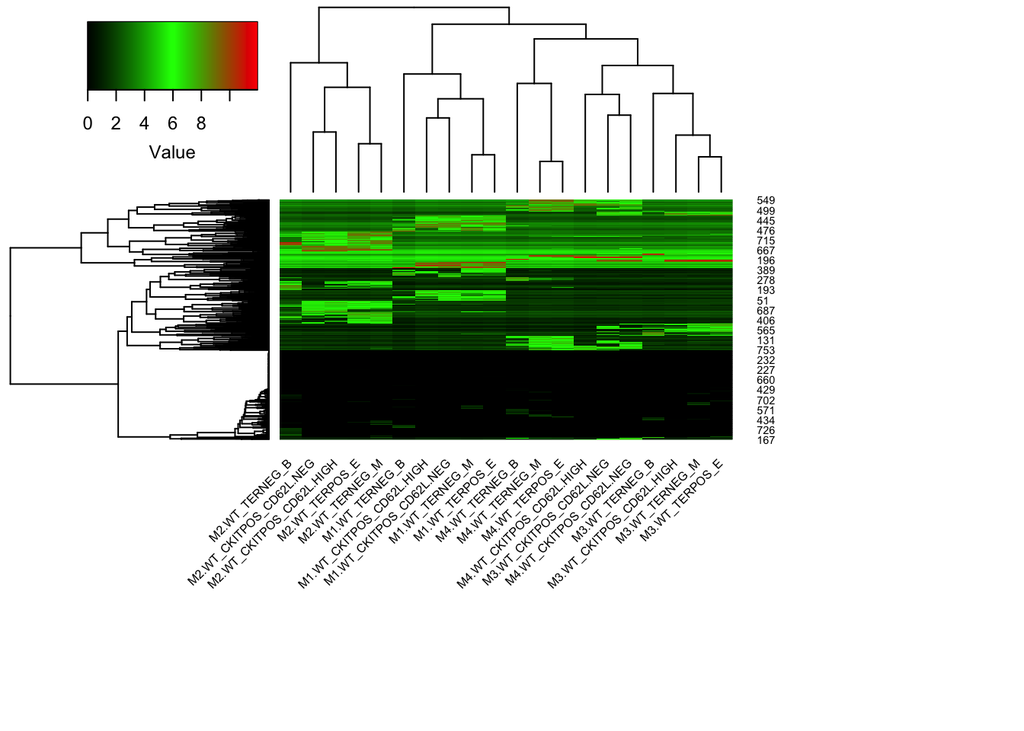

```r
## Plot heatmap

distance<-"euclidean"
clusteringMeth<-"complete"
dendro<-"yes"

p<-plotHeatmap(analysis_matx_wide[,-1], distance,clusteringMeth, dendro)
```

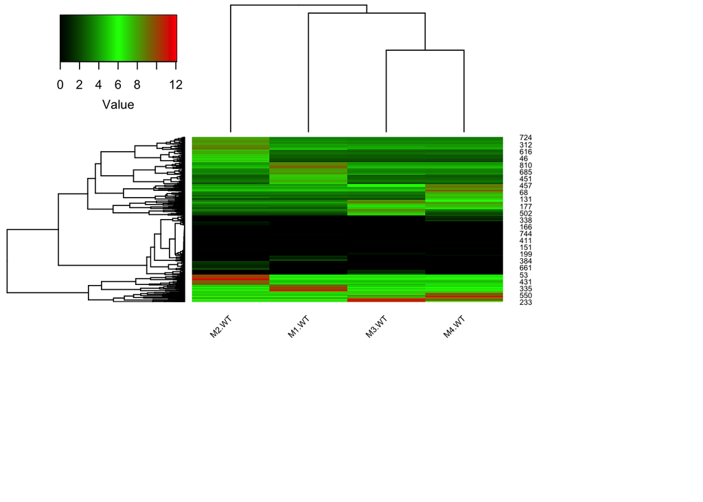

```r
# reformat
matx<-wideToLong(analysis_matx_wide, metadata_analysis )
matx<-filter(matx, counts>0)
matx_mice<-dcast(matx, Barcodes~mouse, fun.aggregate = sum, value.var = "counts")

# plot
p<-plotHeatmap(matx_mice[,-1], distance,clusteringMeth, dendro)
```

## II - 3. True repeat use filtering and false set to 0

```r
####### Matrix with true repeat use deletion and false repeat use barcode abundances set to 0

# from the filtred duplicats matrix, delete duplicats information and take the sum of both
analysis_matx_lg<-lg_filtred
analysis_matx_lg$variable<-str_remove(analysis_matx_lg$variable, "a_")
analysis_matx_lg$variable<-str_remove(analysis_matx_lg$variable, "b_")

# long to wide
analysis_matx_wide<-dcast(analysis_matx_lg, tag~variable, fun.aggregate = sum, value.var = "value")

write.csv(analysis_matx_wide, paste0("outputs_for_Analysis/", prefix,condition,"_ANALYSIS_matx_norm_filt_cor_ab_trueFalseRU.csv"), sep = ",", quote = FALSE, row.names = F)
```

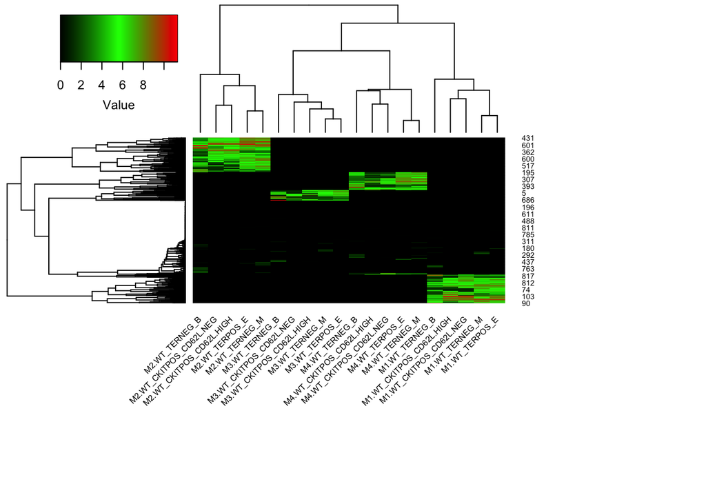

```r
## Plot heatmap

distance<-"euclidean"
clusteringMeth<-"complete"
dendro<-"yes"

p<-plotHeatmap(analysis_matx_wide[,-1], distance,clusteringMeth, dendro)
```

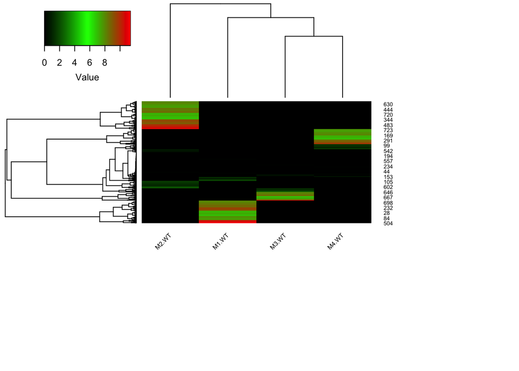

```r
# reformat
matx<-wideToLong(analysis_matx_wide, metadata_analysis )
matx<-filter(matx, counts>0)
matx_mice<-dcast(matx, Barcodes~mouse, fun.aggregate = sum, value.var = "counts")

# plot
p<-plotHeatmap(matx_mice[,-1], distance,clusteringMeth, dendro)
```